# Crypto Price Correlations

# An Analysis of Crypto Price Correlations overtime

```python
class CryptoCorrelationAnalyzer:
    def __init__(self, cryptos: Optional[list] = None):
        """Initialize the analyzer with a list of cryptocurrency symbols."""
        self.cryptos = cryptos or ['BTC', 'ETH', 'XRP', 'DOGE']
        self.data: Dict[str, pd.DataFrame] = {}
        self.combined_df: Optional[pd.DataFrame] = None

    def load_data(self) -> None:
        """Load cryptocurrency data from parquet files."""
        print("📊 Loading cryptocurrency data...")

        for crypto in self.cryptos:
            filename = f'{crypto.lower()}_price_data.parquet'
            try:
                self.data[crypto] = pd.read_parquet(filename)
                print(f"✅ Loaded {crypto} data: {len(self.data[crypto])} records")
            except Exception as e:
                print(f"❌ Error loading {crypto} data: {str(e)}")

    def handle_duplicate_indices(self) -> None:
        """Remove duplicate indices from all dataframes."""
        print("\n🔍 Checking and handling duplicate indices...")

        for crypto, df in self.data.items():
            if not df.index.is_unique:
                print(f"Found duplicate indices in {crypto} data. Resolving...")
                self.data[crypto] = df.loc[~df.index.duplicated(keep='first')]
                print(f"✅ Resolved duplicates for {crypto}")

    def prepare_combined_dataset(self) -> pd.DataFrame:
        """Prepare and return a combined dataset of all cryptocurrencies."""
        print("\n🔄 Preparing combined dataset...")
        self.handle_duplicate_indices()

        combined_df = pd.DataFrame()
        for crypto in self.cryptos:
            if crypto in self.data:
                combined_df[f'{crypto}_close'] = self.data[crypto]['close']
                combined_df[f'{crypto}_volume'] = self.data[crypto]['volume']

        combined_df = combined_df.fillna(method='ffill')
        self.combined_df = combined_df.dropna()
        print(f"✅ Combined dataset prepared: {len(self.combined_df)} records")
        return self.combined_df

    def calculate_correlations(self) -> Tuple[pd.DataFrame, pd.DataFrame]:
        """Calculate and return price and volume correlations."""
        if self.combined_df is None:
            self.prepare_combined_dataset()

        print("\n📈 Calculating correlations...")

        price_cols = [f'{crypto}_close' for crypto in self.cryptos]
        volume_cols = [f'{crypto}_volume' for crypto in self.cryptos]

        price_corr = self.combined_df[price_cols].corr()
        volume_corr = self.combined_df[volume_cols].corr()

        return price_corr, volume_corr

    def plot_correlations(self, price_corr: pd.DataFrame, volume_corr: pd.DataFrame) -> None:
        """Plot correlation heatmaps for price and volume."""
        plt.style.use('seaborn-v0_8')
        fig, (ax1, ax2) = plt.subplots(1, 2, figsize=(15, 6))

        for ax, data, title in [(ax1, price_corr, 'Price Correlations'),
                               (ax2, volume_corr, 'Volume Correlations')]:
            sns.heatmap(data,
                       annot=True,
                       cmap='coolwarm',
                       vmin=-1,
                       vmax=1,
                       center=0,
                       ax=ax,
                       fmt='.2f')
            ax.set_title(title)

        plt.tight_layout()
        plt.show()

    def calculate_rolling_correlations(self, window: int = 30) -> Dict[str, pd.Series]:
        """Calculate rolling correlations between cryptocurrency pairs."""
        if self.combined_df is None:
            self.prepare_combined_dataset()

        print(f"\n📊 Calculating {window}-day rolling correlations...")

        rolling_corr = {}
        for i, crypto1 in enumerate(self.cryptos):
            for crypto2 in self.cryptos[i + 1:]:
                pair = f'{crypto1}-{crypto2}'
                rolling_corr[pair] = self.combined_df[f'{crypto1}_close'].rolling(
                    window=window,
                    min_periods=1
                ).corr(self.combined_df[f'{crypto2}_close'])

        return rolling_corr

    def plot_rolling_correlations(self, rolling_corr: Dict[str, pd.Series], window: int = 30) -> None:
        """Plot rolling correlations for cryptocurrency pairs."""
        n_pairs = len(rolling_corr)
        n_cols = min(2, n_pairs)
        n_rows = (n_pairs + n_cols - 1) // n_cols

        fig, axes = plt.subplots(n_rows, n_cols, figsize=(15, 5 * n_rows))
        axes = np.array(axes).reshape(-1) if isinstance(axes, np.ndarray) else [axes]

        for idx, (pair, corr) in enumerate(rolling_corr.items()):
            ax = axes[idx]
            ax.plot(corr.index, corr.values, linewidth=1.5)
            ax.set_title(f'{window}-Day Rolling Correlation: {pair}')
            ax.set_xlabel('Date')
            ax.set_ylabel('Correlation')
            ax.grid(True, alpha=0.3)
            ax.axhline(y=0, color='black', alpha=0.2)
            ax.set_ylim(-1.1, 1.1)
            plt.setp(ax.xaxis.get_majorticklabels(), rotation=45)

        # Remove empty subplots
        for idx in range(len(rolling_corr), len(axes)):
            fig.delaxes(axes[idx])

        plt.tight_layout()
        plt.show()

    def analyze_extreme_periods(self, rolling_corr: Dict[str, pd.Series], percentile: float = 95) -> None:
        """Analyze periods of extreme correlations."""
        print(f"\n🔍 Analyzing periods of extreme correlations (>{percentile}th percentile)...")

        for pair, corr in rolling_corr.items():
            clean_corr = corr.dropna()
            threshold = np.percentile(clean_corr, percentile)
            extreme_periods = clean_corr[clean_corr > threshold]

            print(f"\n{pair} Extreme Correlation Periods:")
            print(f"Threshold: {threshold:.3f}")
            print(f"Number of extreme periods: {len(extreme_periods)}")

            if len(extreme_periods) > 0:
                print("Top 5 highest correlation periods:")
                print(extreme_periods.nlargest(5).to_string())
```

The CryptoCorrelationAnalyzer class is a sophisticated tool designed to analyze relationships between different cryptocurrencies through their price and volume data. At its core, the class begins by initializing with a list of cryptocurrency symbols and sets up data structures to store the information. The class then loads historical cryptocurrency data from parquet files, performing necessary cleaning operations such as handling duplicate indices before combining all the data into a unified dataset.

The analysis capabilities of the class operate on two main levels. First, it calculates static correlations, producing correlation matrices for both price and volume data across all cryptocurrencies in the dataset. Second, it computes rolling correlations over a configurable time window (defaulting to 30 days), which provides insight into how the relationships between cryptocurrencies evolve over time. This dynamic analysis is particularly valuable for understanding changing market conditions and cryptocurrency pair relationships.

The visualization components of the class are equally robust, offering two primary types of visual analysis. The first is a pair of heatmaps that display price and volume correlations between cryptocurrencies, making it easy to identify strong relationships or divergences. The second is a set of time series plots that visualize the rolling correlations between cryptocurrency pairs, allowing users to track correlation changes over time and identify trends or patterns in the relationships.

```python
# Calculate and plot correlations
price_corr, volume_corr = analyzer.calculate_correlations()
```

```
##
## 📈 Calculating correlations...
```

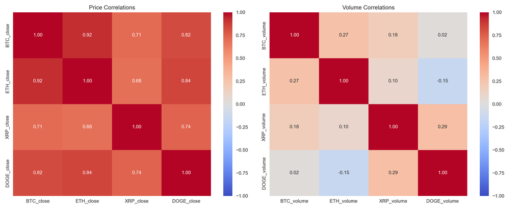

```python
analyzer.plot_correlations(price_corr, volume_corr)
```

### Key takeaways

The overall trend of the correlation between the different cryptocurrencies is that they are highly correlated. This is not surprising given that they are all part of the same market and are influenced by similar factors such as market sentiment, regulatory changes, and technological advancements. However, there are some interesting patterns that emerge when we look at the rolling correlations over time. The least correlated coins are Xrp and ethereum and the most correlated coins are bitcoin and ethereum. This could be due to the fact that ethereum is a fork of bitcoin and shares many of its underlying principles. It is also worth noting that the correlation between the different cryptocurrencies tends to increase during periods of high volatility. This is likely due to the fact that investors tend to flock to the most stable coins during times of uncertainty, which can lead to increased correlations between them. Overall, this analysis provides valuable insights into the relationships between different cryptocurrencies and how they are influenced by market conditions.

```python
# Calculate and plot rolling correlations
rolling_corr = analyzer.calculate_rolling_correlations(window=30)
```

```
##
## 📊 Calculating 30-day rolling correlations...
```

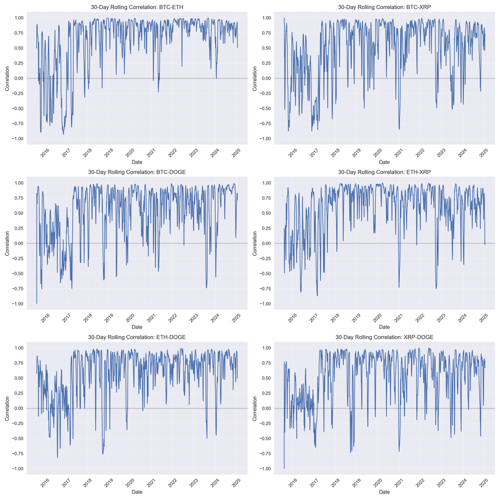

```python
analyzer.plot_rolling_correlations(rolling_corr)
```

```python
analyzer.analyze_extreme_periods(rolling_corr)
```

```
##
## 🔍 Analyzing periods of extreme correlations (>95th percentile)...
##
## BTC-ETH Extreme Correlation Periods:
## Threshold: 0.981
## Number of extreme periods: 173
## Top 5 highest correlation periods:
## timestamp
## 2015-08-04         inf
## 2018-12-06    0.998132
## 2018-12-07    0.997956
## 2018-12-05    0.997887
## 2018-12-08    0.997870
##
## BTC-XRP Extreme Correlation Periods:
## Threshold: 0.964
## Number of extreme periods: 173
## Top 5 highest correlation periods:
## timestamp
## 2015-07-31    1.000000
## 2022-01-23    0.993073
## 2022-01-22    0.992374
## 2022-01-24    0.991078
## 2022-01-25    0.989244
##
## BTC-DOGE Extreme Correlation Periods:
## Threshold: 0.958
## Number of extreme periods: 173
## Top 5 highest correlation periods:
## timestamp
## 2024-11-19    0.989455
## 2024-11-18    0.988540
## 2018-06-07    0.988525
## 2024-11-20    0.987919
## 2024-11-17    0.987779
##
## ETH-XRP Extreme Correlation Periods:
## Threshold: 0.971
## Number of extreme periods: 173
## Top 5 highest correlation periods:
```

[output cut: 13 more lines]

```
## 2022-05-26    0.992202
## 2022-05-25    0.991961
## 2022-05-27    0.988448
## 2022-05-24    0.987947
##
## XRP-DOGE Extreme Correlation Periods:
## Threshold: 0.962
## Number of extreme periods: 173
## Top 5 highest correlation periods:
## timestamp
## 2022-05-25    0.997132
## 2022-05-26    0.996901
## 2022-05-27    0.996330
## 2022-05-24    0.995984
## 2022-05-28    0.995904
```